# Personal Learning: The Effects of Class Size and Urbanicity on 1st Grade Math Performance in STAR Study

Benjamin Jewell

March 18th 2024

# 1 Abstract

The original STAR study worked to find if the size of a classroom for kindergartners through first graders had an impact on their future academic performance. In this study we will study if the classroom size and school urbanicity impacts their math test score. Strict adherence to experimental definitions were employed, to ensure that all classes examined had the correct number of students and those said students had been enrolled in the same class size both years. The median math score of students grouped by their teacher was used to measure their performance. A fixed effects model was fit to the data, with both classroom size and school setting found to be impactful to first grade math scores. Among class types it was concluded that small classrooms lead to higher math scores compared to regular class sizes.

# 2 Introduction

This study is seeking to answer two questions: 1) Is there any differences in math scaled scores in first grade across class types? 2) Which class type is associated with the highest math scaled scores in first grade? One can likely believe anecdotally that in a class packed with students and a sole teacher, the quantity of education is likely diminished compared to a class where students get individual attention. This study seeks to examine this belief, by comparing both small classes to regular classes and regular classes that also have a teacher’s aide. Both of these approaches lead to balancing the student to educator ratio, though in different manners. In performing this study we can hope to discover a better way to educate students to ensure their academic success. Not only can this help their future careers and opportunities, but also leads to a more educated future for society.

In particular, this study focuses on the effects of class size and urbanicity on the first grade median math scores of students who have been participating in the same class size over both first grade and kindergarten. Changes in class size between years dilute the definitions of our class sizes students have participated in, leading to potential confusion when interpreting our results. To ensure a proper understanding of our results this study only focuses on those students whose class size meets the descriptions laid out in the STAR study description. Due to the tight focus of these requirements and to ensure we have proper representation for all treatments our investigation decided to focus on urbanicity rather than individual schools. In using urbanicity, we can have at least five observations per treatment, while if we had examined individual schools not all treatments would have even one observation.

# 3 Background

Known as the Tennesses Student/Teacher Achievement Ratio study (STAR), this project focused on the benefits of classroom sizes for students and was a study mainly conducted in 1985 to 1989. The study focused on students in kindergarten and first through third grade, recording their math and reading scores those four years. Data was collected for a wide number of factors, from class size, to the education of a given teacher, and many more. Further analysis would be conducted over twenty five years to examine the long term benefits for these students.

The STAR study sought to further understand the difference in classroom size, which until then had data which was confusing and unclear due to various counting methods (Achilles, 2012, p. 1). In performing their own experiment, the investigators sought to find a clear and definitive answer to the effects of classroom size on the education of their students. It was hoped that a stronger method for teaching children could be discovered.

# 4 STAR Experimental Design

The target students in this study were in 79 different schools throughout Tennessee in kindergarten, who would be tracked for their adolescent academic lives. The schools in the study were of a variety of types including inner city schools, rural schools, urban school and suburban schools. Any appropriate school within Tennessee could join the study, allowing for a broader scope in what schools were included. Schools had to meet a minimum pupil count in the first year to join, allowing for 79 schools to be part of the study the first year. Due to the variety of schools and locations used the study designers believed they had allowed for a reasonable representation of different incomes and ethnicity among the students (Achilles, 2012, p. 6).

The study tracked students starting in kindergarten, with varying classroom types prescribed to them by the STAR project through third grade. With approximately 7,000 students to begin with, these students were each randomly assigned to one of three classroom types: small classrooms (13-17 students), regular classrooms (22-25 students) and regular classrooms with an aide to assist the teacher. Students were placed into the same class size if possible between years. One major change to the study was made after the first year in this regard: of the students marked for regular classrooms half were randomly selected to be placed into a regular class with an aide, while half of the students in a regular classroom with an aide were randomly selected to be moved into a regular class. Similar to the students, teachers were randomly assigned classroom types to avoid any issues with teachers specializing in teaching particular sizes of classrooms. Besides the demand for classroom size no other changes were made to allow for a normal school environment.

Compared to many similar studies the STAR project sought to focus specifically on the size of a given class rather than the pupil-teacher ratio (PTR). This allows for a clear understanding of how many students are involved in a given classroom, for a class with two teachers and 60 students will have the same PTR as a class with one student and 30 students. The use of classroom size in STAR allows for a more direct analysis on the educational benefits of the number of students in a given classroom.

It should be noted that while the STAR program began with approximately 7,000 students not all students were retained over the course of the study. The program did not force students to stay in the project students, and students may have left for a variety of reasons such as moving to a different city or state, or having to drop out of school. After the first year, three of the 79 schools had dropped from the program.

Not only did students leave the program, but because the STAR study examined specific schools and not students, any students who joined a STAR school were enrolled into the study. These students would not have had the controlled classroom size from previous years of the study, and could only benefit from the years they were in the study but no note is made to exclude them. To compound this issue, at the time this study was conducted kindergarten was not mandatory in Tennessee, meaning many students joined the program for the first time in first grade and missed a whole year of STAR class size.

Compared to many other studies on the subject of classroom size, STAR sought to measure the long term benefits of class size using a multitude of factors, and as previously mentioned, with a much clearer metric on class size compared to PTR. As we have stated, there are challenges with this study, but the data we are provided is rich with information for examining just how well class size effects the performance of students.

# 5 Initial Analysis

Previous examinations have been made of this data set in an initial analysis report. Initial inquiries into the first grade math scores looked for a relationship between the class type and specific schools. The initial investigation had a broader stroke, simply looking at students who had math scores in the first grade. No relationship between the numerous missing values throughout the data set had been discovered at this point, so the data was dropped haphazardly without thought.

As put forth by the analysis guidelines, the investigation used an additive two way ANOVA model with no interaction. While the model indicated that both class type and school ID had an effect on the first grade math scores, there were several issues with the model used. In investigating model assumptions, several were found to be broken, namely the normality and equal variance. As such, any conclusions that this initial analysis report might have made are not valid, only serving to familiarize us with the problems we will face in this study.

# 6 Descriptive analysis

For our analysis we concerned ourselves with five variables, , `g1tmathss` , `g1tchid`, `g1classtype`, `g1schid`, and `g1surban`. Each of these five variables corresponds to a student in the first grade, tracking their progress in the STAR project. In order, our five variables are:

- `g1tmathss`: The math score of a given student in the first grade.
- `g1schid`: The ID of the school a given student is at.
- `g1tchid`: The ID of the teacher who is teaching a given student.
- `g1classtype`: The type of class the student is enrolled in, with levels `small`, `regular` and `regular+aide`.
- `g1urban`: The urbanicity of the school the student is enrolled in, with levels `inner city`, `suburban`, `rural` and `urban`.

## 6.1 Summary of First Grade Math Scores

We can see that we have a mean math score among first grade students of 530.53, a median score of 529, a lower quartile of 500 and higher quartile of 557. There is a standard deviation of 43.11 among the grade 1 math scores. Of particular note is the large amount of missing data points in the data, as denoted by `Total_NAs` below, making up more than a quarter of the data. This is no insignificant portion of the data, so we will need to investigate this further below.

Table 1: Summary statistics of 1st grade math scores

|  | Mean | Standard Deviation | Q25% | Q50% | Q75% | Total Missing | Total Data |
| --- | --- | --- | --- | --- | --- | --- | --- |
|  | 530.5279 | 43.10868 | 500 | 529 | 557 | 5003 | 11601 |

## 6.2 Missing Values and STAR Project Inconsistencies

### 6.2.1 Proportion of Missing Values

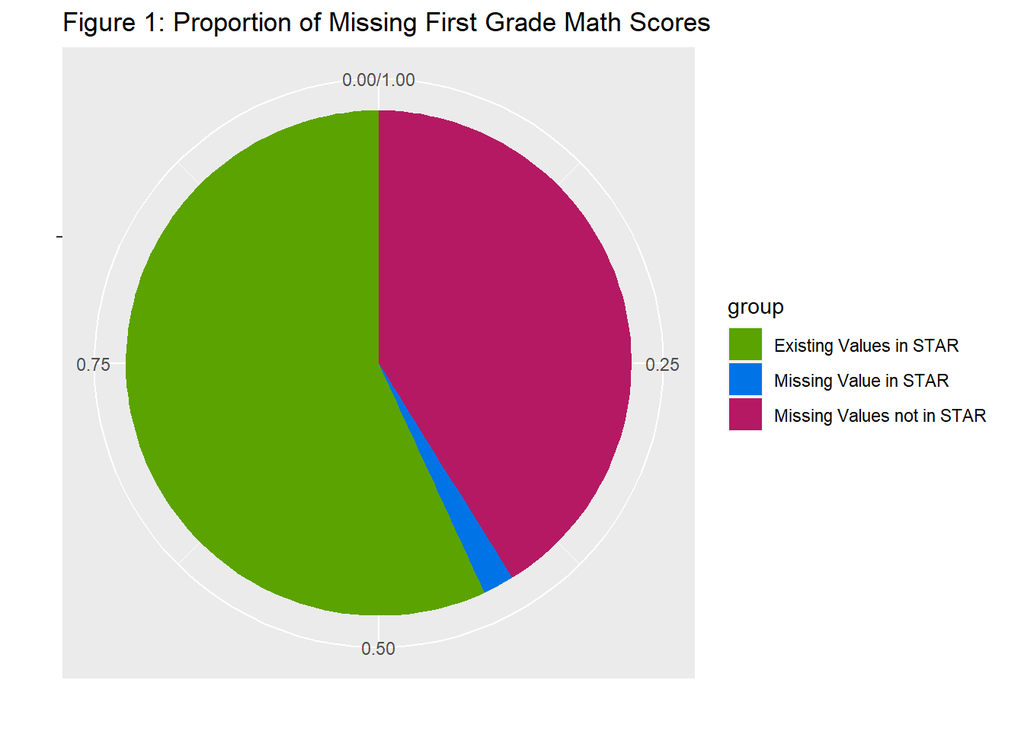

### 6.2.2 Class Size Inconsistencies

In our examination we will want to investigate the data to ensure that it complies with the definitions set up in the project. As explained in the STAR Experimental Section, the size of a small class is defined as a class with 13 to 17 students, while the other classes contain 22 to 25 students. We can find that a number of classes deviate from these assumptions. In total, only 89.14% of classes defined as small are actually small, and only 58.50% of regular sized classes are actually regular. To ensure that proper adherence to the experimental design is met those classes that fail to adhere to their initial definition will be removed from our investigation.

### 6.2.3 Consistent Class Type

To ensure that students are complying with the class type they have been assigned to, we checked that students were enrolled in the same size of class across the two years examined. Any students who deviated from this requirement had have a mixed education and could not be clearly placed in one education type or another. As such, we drop these mixed students from our study.

There are two major notes in doing this that must be stated. First, this process will remove any students not enrolled in first grade or kindergarten. As we are looking at the effects of a given class type across both kindergarten and first grade there appears to be little issue here. It should be noted, however, that in Tennessee when the study began kindergarten was not mandated, thus limiting the scope of this study to kids whose parents sent them to kindergarten. Secondly, after the first year, the STAR study designers decided to modify their experiment in the following manner: Half of the students in the ‘regular’ class size were randomly assigned to ‘regular + aide’ class size, while half of the ‘regular + aide’ students were randomly selected to be moved to the ‘regular’ class size. Due to this deviation from the initial study designs we will have to drop these students as they deviate from our own investigation on the effects of subsequent class sizes.

### 6.2.4 Dropping Data Points

Because the proportion of missing students makes up less than 2% of our data set we can be assured that we have enough remaining students per school to continue with our study. As such, the remaining 1.5% of students with missing first grade math scores will be dropped from the study we are conducting.

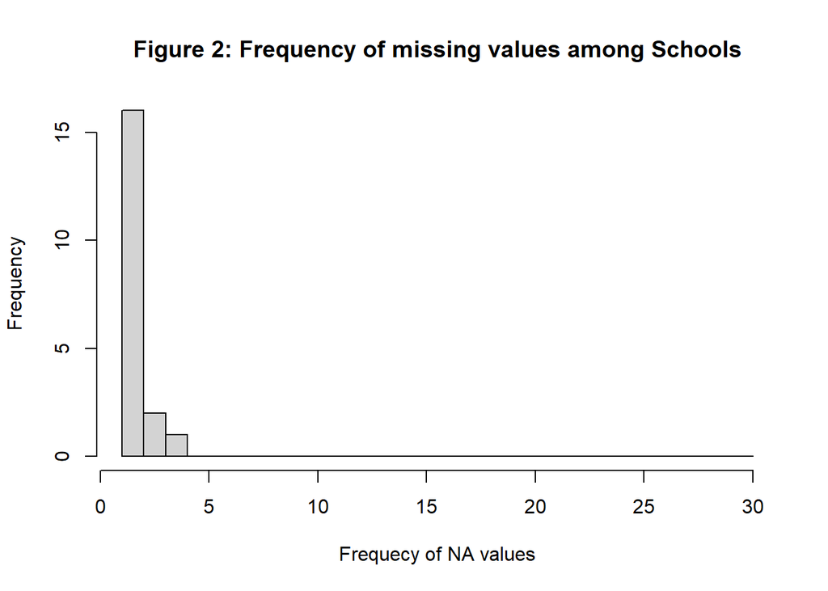

## 6.3 Aggregated Teacher Statistic

When examining the first grade math scores between students we cannot simply use the individual scores due to high correlation between students in a single class. Because they are taught in the same setting and in the same manner, a high correlation develops between them. Instead the median score of such a class is considered. To take the problem a step further, students taught by the same teacher are likely to have issues of correlation as well since teaching style likely only differs so much between classes taught by the same educator.

Taking this all into consideration, we use the median score of all students taught by a single teacher as our statistic of interest in this study. The median was chosen over the mean as it will not be affected by outliers, and in previous investigations it was found that using the mean results in a model that deviates from key model assumptions.

### 6.3.1 Median Math Score: Summary Statistics

Examining the new median statistic score per teacher we can find that there is a median score of 536.5, a standard deviation of 31.11, a lower quartile of 515 and upper quartile of 557. As seen in Figure 3 the median math score per teacher is somewhat normally distributed, but appears to have a heavy tail.

Table 3: Summary Statistics for Median Scores per Teacher

|  | Median Test Scores per Teacher |
| --- | --- |
| Mean | 535.77468 |
| Std Dev | 31.10514 |
| Q25% | 515.00000 |
| Q50% | 536.50000 |
| Q75% | 557.00000 |

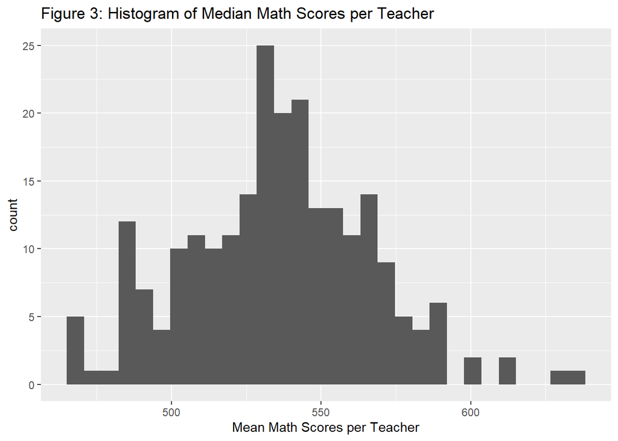

### 6.3.2 Class Types: Summary Statistics

Examining the statistics of various class types we can see in the boxplot comparison small classes have higher medians and quartiles compared to regular classes, but potentially equal medians to regular classes with aides (Figure 4). Obviously actual testing will need to be performed to confirm this visual inspection. The various summary statistics for each class type can be seen in Table 4, which supports our visual inspection of the boxplots.

Table 4: Summary Statistics per Class Size

|  | Small Class | Regular Class | Regular + Aide Class |
| --- | --- | --- | --- |
| Mean | 542.52752 | 524.9565 | 535.96364 |
| Std Dev | 30.41471 | 31.6633 | 28.32971 |
| Q25% | 523.00000 | 501.5000 | 514.75000 |
| Q50% | 542.00000 | 527.5000 | 538.00000 |
| Q75% | 562.00000 | 542.0000 | 558.25000 |

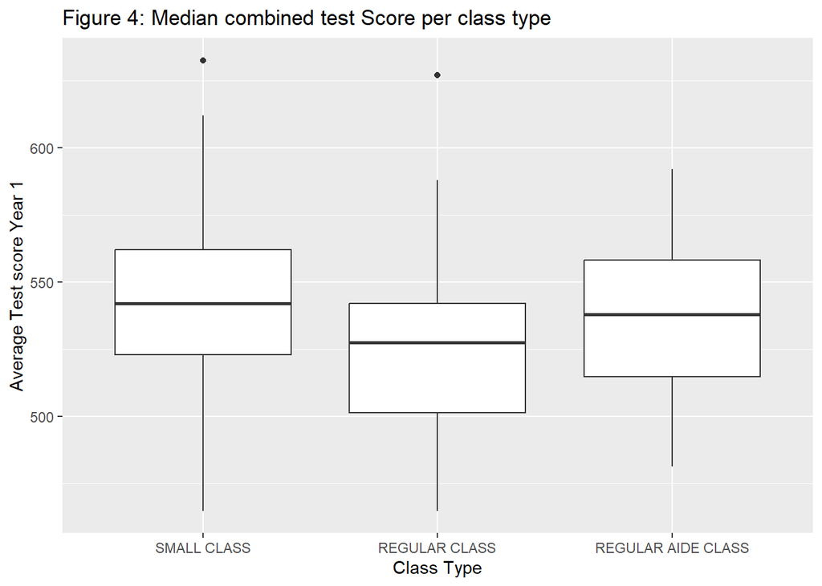

### 6.3.3 School Urbanicity: Summary Statistics

Below we can see the summary statistics for the urbanicity of each school can be seen in Table 5. As seen in Figure 5 we have compared the median math scores per individual school, with coloring per school urbanicity to differentiate between them. Figure 6 displays a boxplot of median math scores per urbanicity level, where we can see that inner city schools have lower medians than the other three settings which are approximately equal.

Table 5: Summary Statistics per School Setting

|  | Inner City | Suburban | Rural | Urban |
| --- | --- | --- | --- | --- |
| Mean | 508.62245 | 541.60577 | 542.52294 | 548.45652 |
| Std Dev | 28.27332 | 28.01091 | 26.93394 | 31.02672 |
| Q25% | 487.00000 | 521.75000 | 526.50000 | 529.50000 |
| Q50% | 505.00000 | 542.00000 | 540.00000 | 552.00000 |
| Q75% | 532.00000 | 558.25000 | 559.50000 | 569.00000 |

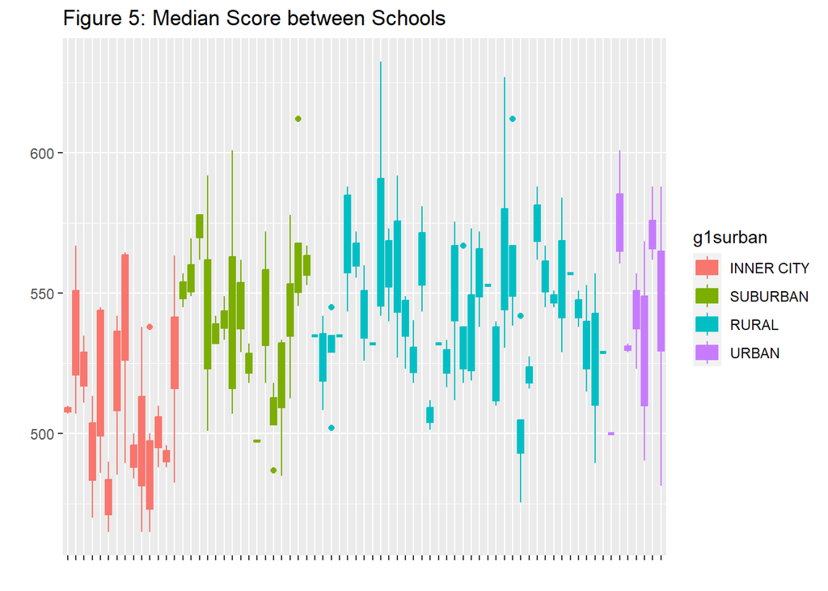

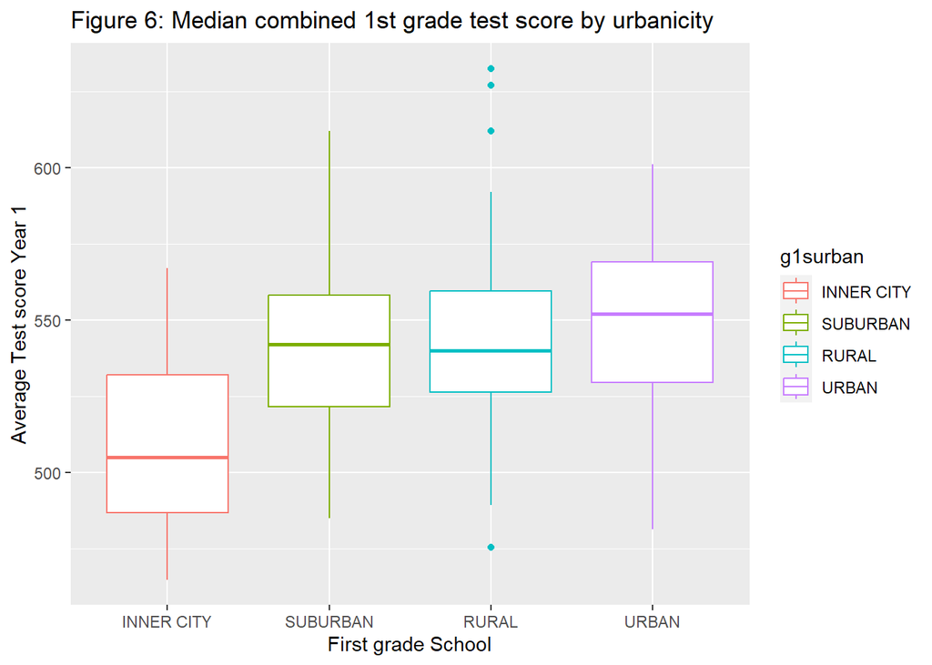

### 6.3.4 Examining distribution of Urbanicity and Schools

It should be noted that in adhering to the caveats of our study the size of our dataset has been trimmed down to a little over half the initial data. As such when examining the median scores of a given teacher we should ensure that there is enough data to move forward. Below two plots have been made to highlight the portion of students in each treatment when using school ID compared to urbanicity as our variable to represent location. As we can see not all levels of class size can be found in each school (Figure 7). Comparatively when representing school location by urbanicity we have a minimum of five units per treatment, though it should be noted that there is much higher proportion of rural classes (Figure 8).

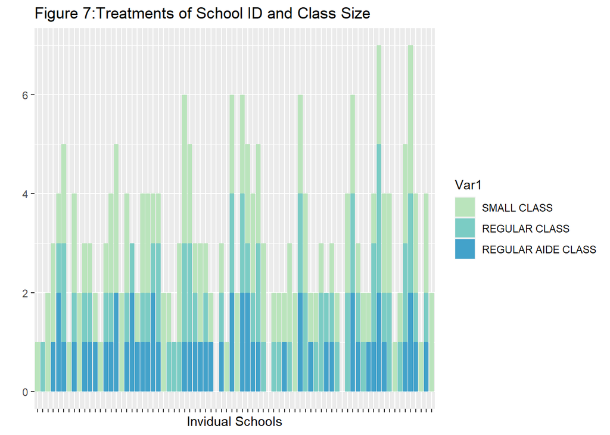

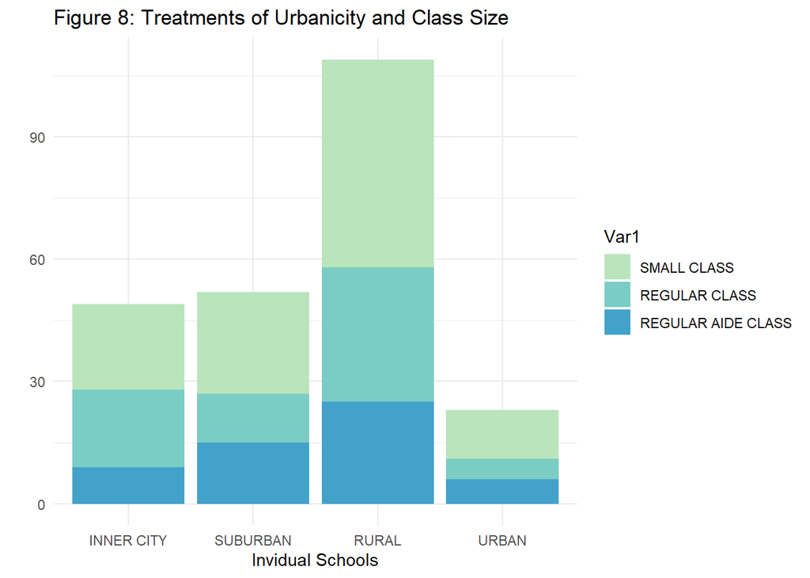

# 7 Inferential analysis

## 7.1 Modeling

Our initial analysis report was directed to use a model that accounted for class type and individual schools. However, we have seen (Figure 7, Figure 8) that to ensure that all treatments are represented in our model, urbanicity will need to surplant the use of school ID. Because each school belongs to a single type of urbanicity there exists a straight forward mapping between individual schools and the level of their urbanicity. Using the urbanicity of the school, readers of this report may be able to gauge how effective class size can be for their specific school.

We will be fitting a fixed effect model for the data given, using the class type and school urbanicity as our independent variables and the median math score per teacher as our response variable. Due to the fact that there is an imbalanced number of observations per treatment we will choose a type II model.

### 7.1.1 Model Assumptions

An imbalanced type II fixed effect ANOVA model was chosen to be fit to our data, with the following equations:

$$Y_{ijk} = \mu_{..} + \alpha_i + \beta_j + \epsilon_{ijk} \\
i \in \{1,2,3\}, j =1,...,4, k=1,2,...,n$$

In this case our variables are:

- $\mu_{..}$ : Mean response across all indexes.
- $\alpha_i$ : The main effects of the fixed variable school urbanicity.
- $\beta_j$ : The main effects of the fixed variable class type.
- $\epsilon_{ijk}$ : The random error for entry (i,j,k).

### 7.1.2 Model Fitting

We will be performing an F-test for both of our variables, class type and school setting, to see if they are significant at $\alpha = 0.05$. We will be testing the following hypothesis:

$$H_0: \alpha_i = 0 \text{ }\forall i. \\
H_1: \text{Not all }\alpha_i\text{ equal zero.}$$

As well as:

$$H_0: \beta_j = 0 \text{ }\forall j. \\
H_1: \text{Not all }\beta_j\text{ equal zero.}$$

Our tests return a p-value of less than 0.01 for the main effects of class size, indicating that class size has effects on the math scores of students. Similarly a p-value of less than 0.01 was also returned for the main effects of urbanicity, indicating that the urbanicity of a given school will effect the math scores of students.

### 7.1.3 Test for Interaction

A test for interaction terms was also performed at significant level $\alpha = 0.05$, testing the following hypothesis:

$$H_0: (\alpha\beta)_{ij} = 0 \\
H_1: \text{not all } (\alpha\beta)_{ij} \text{ are zero.}$$

Because of the results of these tests we will not be including an interaction term in our model. It should be noted that the residuals of the interaction model are not normal, but further discussion of this deviation will be conducted in the sensitivity section.

## 7.2 Effects Plots & Interaction Plot

An investigation into the effects leads to examining the main effects plot. The main effects of class type can be seen in Figure 9, where it appears that a smaller class type has a strong effect on median math score compared regular classes, further supporting our suspicions drawn from the boxplots earlier (Figure 4). This will be of particular note when answering our secondary question below. In Figure 10 we can see the main effects of the school setting, with a Inner City schools having a significant decrease in median math scores compared to the other school locations.

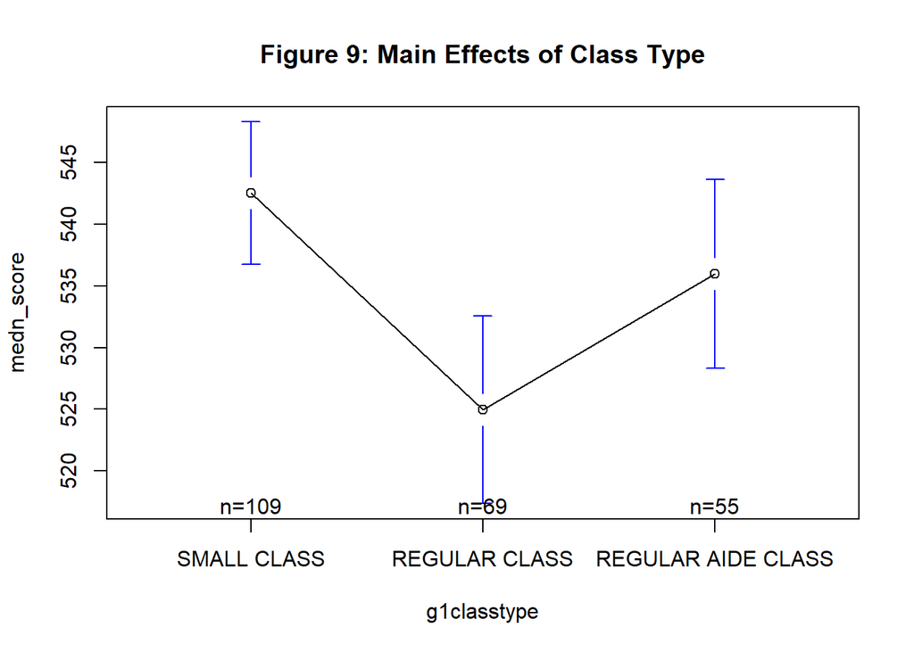

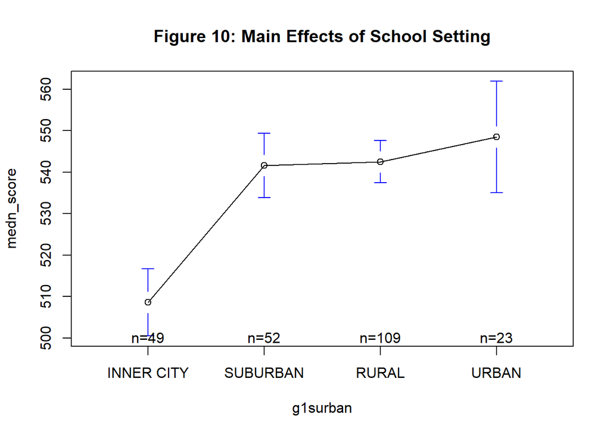

## 7.3 Secondary Question of Interest:

Let us perform the Tukey Range test at significance level $\alpha = 0.05$. The Tukey Range test examines all pairwise differences in the means between different levels in a given treatment. This test has the following assumptions

- $Y_{ijk}$ are independent within their group and between groups
- Each group is normally distributed
- Homogeneity of variance between the group variances.

The Tukey Range test will be used to perform an examination to discover if any class type has a higher mean summary score than other class types. In particular we will be testing the following null hypothesis, $H_0: \mu_i = \mu_{i'}$ where i and i’ are the three levels of the STAR class type.

Among students that participated in the same classroom setting both years, students who are a part of smaller classes have higher first grade math scores than those in a regular setting. Due to a lack of significance no comparison can be made between regular and regular classes with aides or between small classes and regular classes with aides.

# 8 Sensitivity analysis

## 8.1 ANOVA Assumptions

Let us test the various assumptions of our model to ensure that we do not deviate away from them.

### 8.1.1 Normality in Residuals

One assumption of particular note here is that of normality. In examining our residuals vs fitted plot (Figure 11) we can see that there is little pattern to the data points, indicating no major issues with variance or mean. In examining our residuals via histogram and qqplot (Figure 12, Figure 13), there is little indication of non-normality, and this is confirmed with a Shapiro-Wilk normality test at $\alpha = 0.05$. With a p-value of 0.08 reported, we fail to reject our null hypothesis that our data is normal.

As previously mentioned, there is a breaking of the normality of assumption among our interaction model. By performing a similar Shapiro-Wilk normality test we report a p-value of 0.04, indicating the data is non-normal, leading to questions of if the elimination of the interaction term via the F-test is value. However, as stated in Glass et al. (1972) “Skewed populations have very little effect on either the level of significance or the power of the fixed-effects model F-test”. This skewness of the residuals in the interaction model can be seen in Figure 14, which is slightly skewed right. Because this skewness is not particularly strong we can move forward knowing this departure of normality will not strong effect our F-tests.

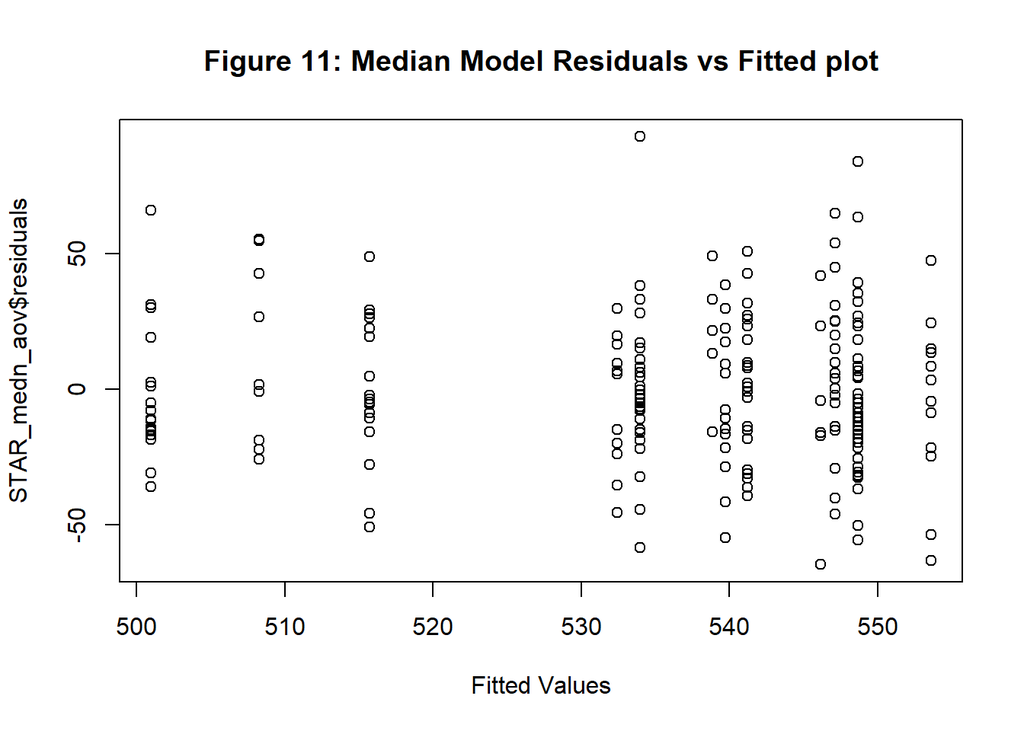

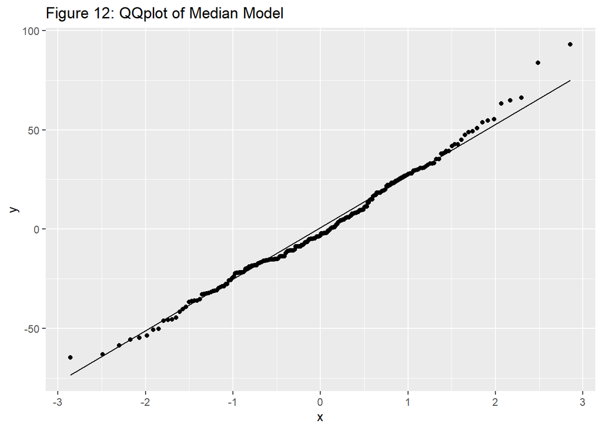

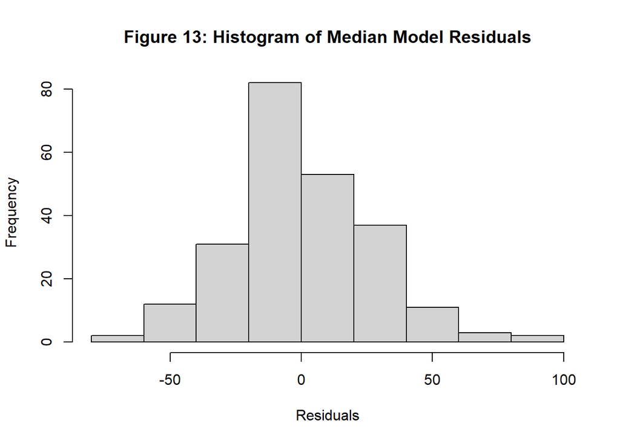

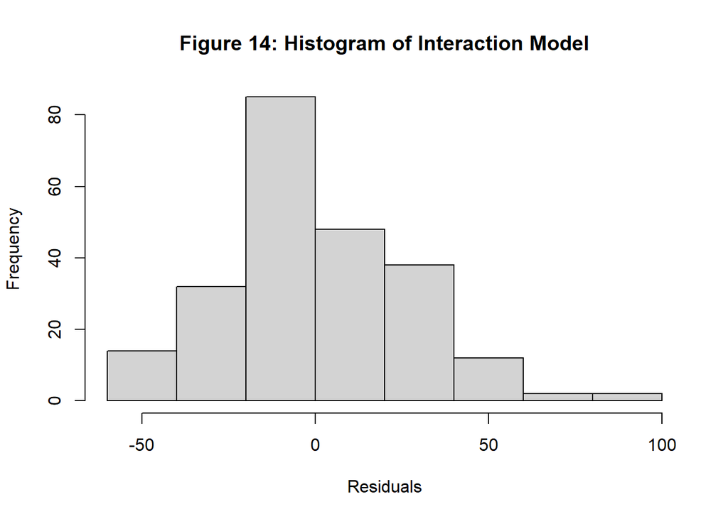

### 8.1.2 Levene Test for Equal Variance

Testing for equal variance among groups, a Levene Test was performed at significance level 0.05. We will be testing if the variance among populations is equal, with the follow null and alternative hypothesis.

$$H_0: \sigma^2_1 = ... = \sigma^2_n$$

$$H_1: \sigma^2_i \neq \sigma^2_j \text{ for all } i\neq j$$

The results of the Levene test indicate no presence of unequal variance among levels of class type, nor among levels of school setting. As equal variance is a key assumption in our fixed effects model this test indicates we need not worry about such depatures.

### 8.1.3 Independence

Unfortunately because we are only involved in analyzing the data and not designing the experiment we must trust in how the Tennessee general assembly set up the experiment. Independence can be seen in the random assignment of class type to each class. Any correlation that might be present among students of the same teacher has also been eliminated by the use of our median summary statistic.

### 8.1.4 Cook’s Distance: Influential Points & Outliers

Using Cook’s distance one can look for outliers and influential points that might effect our model. The following plot, Figure 15, indicates that there are few points that differ from the major of values. Those few values that have a large Cook’s distance compared to the rest of the data set have values so small they don’t approach being influential, thus they are neither outliers. Thus no adjustments need to be made to deal with influential points or outliers.

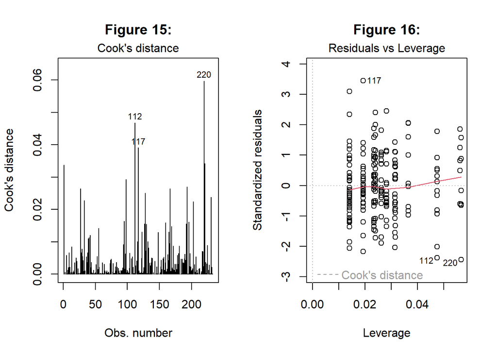

## 8.2 Sensitivity of Model

### 8.2.1 First Grade Data - Urbanicity

Our current data set and model focuses only on students who have the same class size between kindergarten and first grade. However we should examine the effectiveness of our model when presented with only students in first grade who are enrolled in STAR. Similarly we will increase our scope to allow for students who are in classes who do not meet the strict class size requirements to be included in the data set.

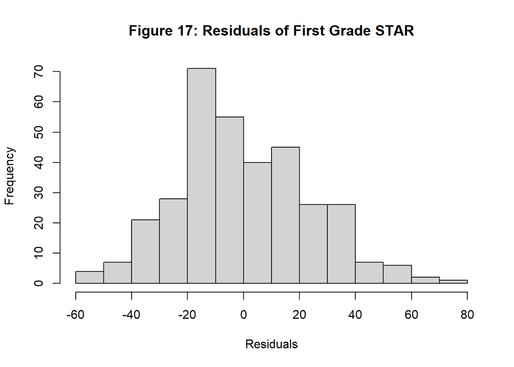

As with our primary model, under these conditions this type 2 imbalanced ANOVA model agrees with our earlier conclusions that both class type and urbanicity are significant. Both class type and urbanicity report a p-value less than 0.01, meaning we reject our null hypothesis.

It appears that our model continues to focus when faced with a greater scope of the STAR project data. It should be noted with greater data points the need to use urbanicity decreases, but none the less we should not overlook that the model continues to work with such variety of data.

### 8.2.3 First Grade - Individual schools

A minor investigation is placed here on the use of School ID as a predictor over urbanicity when solely looking at the first grade class type among students. Similar to our other investigation into first grade scores the only requirement is that students be enrolled in STAR in first grade.

While this model notes significant p-values for both predictors (<0.1 for class size and school ID), unequal variance continues to present itself as an issue when school ID is used. Due to this issue of heterogeneous variances this model must also be discarded, continuing to show the strength of urbanicity over individual schools.

### 8.2.4 Non-Parametric Class Type Comparison

To test our question regarding if any class size performs better than others we had previously employed the Tukey Range test. To further investigate this question however we will turn to another tool, the Dunn test. This test is a non-parametric test, meaning that no assumptions are made about the distributions of our data. The Dunn test will check if there are any differences in the medians between each group, using the t-test to do so. In particular it will use the follow null and alternate hypothesis at $\alpha = 0.05$:

$$H_0: \text{There is no difference in median math scores between class
types} \\H_1: \text{There is a difference in median math scores between
class types}$$

For the difference between regular classes and regular classes with aide we report a p-value of 0.046, indicating the median math scores of regular classes with an aide is higher than those of a regular class. When comparing regular classes and small classes a p-value of less than 0.01 is reported, indicating that the median math scores of small classes is higher than those of regular classes. Finally, in comparing regular classes with an aide to small classes a p-value of 0.23 is reported, indicating there is no difference in median math scores between these two class types.

When our comparison is done in a non-parametric form slightly different results are revealed, that regular classes with aides have higher median scores than regular classes. It should be noted that the Dunn test works specifically for the median, while the Tukey range test measures via the mean. This could be the result of the discrepancy. Under this non-parametric test we can say that regular classes are out performed by both of class types in the STAR project.

# 9 Discussion

In this project we have explored the effect of classroom size on the test scores of students in relation to the urbanicity of the school they are taught in. Student scores were aggregated into median scores per teacher to avoid issues of correlation. We fit a fixed effect model, using a variety of parametric and non-parametric tools to examine the data.

## 9.1 Study Conclusions

With this work we conclude that both class type and school urbanicity have statistically significant main effects on the median first grade math test scores of students. Because the model contains an no interaction term we can also conclude that the effects of class size and urbanicity do not come together to have a greater or lesser effect on a given treatment.

Regarding our secondary question, we can conclude that the median first grade score of students taught in a small classroom setting score higher on the math tests than students taught in regular size classrooms. No comparison can be made between regular classrooms and regular classrooms with an aide. Similarly no comparison can be made between small classrooms and regular classrooms with an aide. Because of this we cannot say that a small classroom has a definitively better performance than all other classrooms in this study.

## 9.2 Limitations and Challenges

It should be noted that while our model does not violate any model assumptions it does not mean our model is without limitations. To begin we were forced to deviate from the suggested use of school ID to measure effects on specific schools to allow for all treatments to have one or more representations.

In examining the design of project STAR there are a number of issues that limit the scope of our own investigation and model. Looking in a broader sense, the issue with imbalanced data limits the models we can fit to our data. For example school ID and class type cannot be used as a predictor due to unequal variances, however this would have not been an issue if the use of a balanced model was allowed.

Project STAR also focuses on students in a particular class size over four years, but has many notable issues maintaining this focus. To begin with, not all children were required to attend kindergarten, so only students who have parents who chose to enroll them in kindergarten participate in the full scope of the study. This can likely effect certain populations such as those in rural settings, who might not have an easy to access kindergarten. Similarly, issues of students changing class types between kindergarten and first grade by the STAR experimenters effects the breadth of our own study.

Because of issues with how the study was conducted, the aggressive trimming of data employed likely limits the general effectiveness of our model and the variety of settings it can comment on. The population of students actually examined is much smaller because we used such strict requirements. One potential future examination could be allowing for small classes to include any student with 19 or fewer students, while classes with 20 or more students count as regular or regular with aide classes.

While urbanicity and individual schools are linked, urbanicity is by no means the same as looking at individual schools. It was hoped that using urbanicity over individual schools would allow for a more applicable model given the data we were examining. Beyond this obvious inequality, issues with urbanicity should not be overlooked. Under our data set rural schools were by far the most represented setting, about as large as inner city and suburban settings combined. Meanwhile urban settings were under represented in our data, with far fewer data points than the rest. While all class types are represented in this data set, ideally there would be an equal number of class types among urbanicity levels.

Another issue that arises from our use of urbanicty is the way inner schools are defined by the STAR project. Any school with more than half the students on free lunches or discounted lunches are defined as inner city, compared to the other three urbanicity levels which are defined by geographic and population examination. While broadly there may be differences in the economic levels of urban, suburban and rural setting, the fact that inner city is tied directly to school lunches and thus the economic position of families sending their kids to these schools makes inner city different than the other three school settings. All definitions are ultimately human made, however the use of urbanicity would likely be strengthened if all four levels were instead tied to economic status.

## 9.3 Future Applications

Future investigation into this subject is recommended so that a stronger conclusion can be reached regarding how to improve the mathematical understanding of first graders. To begin simply adding more students to the study would alleviate our need to use urbanicity over individual schools, allowing for a closer examination. Similarly, ensuring that enough students are retained to allow for a balanced design will lead to more robust models. Finally, simply performing the experiment again today would likely lead to a better data set due to the requirements for students to attend kindergaten. Together these changes could lead to a more robust experiment and data set, allowing for investigators to make stronger and broader conclusions about how to improve schools for first grade learning.

Due to the fact that this study indicates that class size and urbanicity of a school do impact the first grade math scores, it would be advisable for school administration to consider impliment changes similar to the STAR project. As we have shown that small classes perform better than regular classes, the implementation of small classes can lead to students performing better in mathematics. If we are to consider the results of our non-parametric test as well, then adding teacher aides to regular classes can also lead to stronger mathematics in first graders.

## 9.4 Closing Remarks

This study has conducted an investigation into the relationship between classroom size and urbanicity on the median math scores of students in the first grade, using the STAR project data set. This investigation was done with a strict focus ensuring that students were both in the same class size between kindergarten and first grade, and that all class sizes met the particular definitions set by the investigators. Due to these strict limitations on our data we will also have strict limitations on our analysis and conclusions.

Our model is not without issues as discussed in the above section. We have had to change our focus from individual schools to the broader urbanicity of schools, while at the same time focusing on a strict subset of the STAR students. The conclusions from this model should only be applied when the students have been placed in a classroom with 13 to 17 students or 22 to 25 students, and have maintained that class size over both first grade and kindergarten. The size of classroom a student is placed in and the urbanicity setting their school is in will effect the median math scores of their class in first grade. Among these classes, we can conclude that those students that are in small classes will score higher than those in regular classes.

# 10 Conclusion

The STAR program’s investigation into classroom size on educational performance has give us insight into the relationship between these factors. The particular study we performed indicated that classroom size and school setting had an impact on the first grade math scores of students in Tennessee. With this study, school administration can work to adjust their schools to better the education of their pupils, allowing for a brighter and more educated future generation.

# Acknowledgement

Thank you to the following classmates: Sara A, Leena Q, Ian D, Jaehwan K, Lubaba A, Patrick, Jack

A special thank you to Sara A, the STA 104 TA under Dr Andrew Farris, for assistance in understanding non-parametric models.

# Reference

Achilles, C. M., & Shiffman, C. D. (2012). Class-size policy: The STAR experiment and related class-size studies. *NCPEA Policy Brief*, *1*(2), 1–9.

Boluda, M., & starja. (2021, April 5). *Ordering boxplots based on two factor variables (in x-axis) with GGPLOT2*. Stack Overflow. https://stackoverflow.com/questions/66951931/ordering-boxplots-based-on-two-factor-variables-in-x-axis-with-ggplot2

Folger, J., & Breda, C. (1989). Evidence from Project Star about class size and student achievement. *Peabody Journal of Education*, *67*(1), 17–33. https://doi.org/10.1080/01619569209538668

Glass, G. V., Peckham, P. D., & Sanders, J. R. (1972). Consequences of failure to meet assumptions underlying the fixed effects analyses of variance and covariance. *Review of Educational Research*, *42*(3), 237. https://doi.org/10.2307/1169991

Lix, L. M., Keselman, J. C., & Keselman, H. J. (1996). Consequences of assumption violations revisited: A quantitative review of alternatives to the one-way analysis of variance “f” test. *Review of Educational Research*, *66*(4), 579. https://doi.org/10.2307/1170654

Tim. (2022, December 12). *Dunn’s test: Definition*. Statistics How To. https://www.statisticshowto.com/dunns-test/

# 11 Code Appendix

```r
knitr::opts_chunk$set(fig.pos = 'H')
library(AER)
library(ggplot2)
library(tidyverse)
library(foreign)
library(gplots)
library(car)
library(FSA)
library(knitr)

STAR = read.spss("../STAR_Students.sav", to.data.frame = T)
STAR$g1schid = as.factor(STAR$g1schid)
#Summary stastistics of 1st year math scores
g1smath_stats = data.frame(
        Mean = mean(STAR$g1tmathss, na.rm = T),
        Stddev = sd(STAR$g1tmathss, na.rm = T),
        q25 = quantile(STAR$g1tmathss, probs = 0.25, na.rm = T),
        q50 = quantile(STAR$g1tmathss, probs = 0.50, na.rm = T),
        q75 = quantile(STAR$g1tmathss, probs = 0.75, na.rm = T),
        Total_NAs = sum(is.na(STAR$g1tmathss)),
        Total_data = length(STAR$g1tmathss)
        )

colnames(g1smath_stats) = c('Mean', 'Standard Deviation', 'Q25%', 'Q50%', 'Q75%', 'Total Missing', 'Total Data')
rownames(g1smath_stats) = c('')
kable(g1smath_stats, caption = 'Table 1: Summary statistics of 1st grade math scores')

#How many math scores are NA out of the total?
tot_raw_na = sum(is.na(STAR$g1tmathss)) / length(STAR$g1tmathss) #BAD!

#Alternatively using the STARGS1 Flag
tot_star_na = sum(is.na(STAR$g1tmathss[which(STAR$FLAGSG1 == 'YES')])) / length(STAR$g1tmathss[which(STAR$FLAGSG1 == 'YES')])


#Number of non-NA values in g1math
not_na = 1 - tot_raw_na
#Number of NA values in g1math that are enrolled in star (FLAGSG1 = T)
star_na = sum(is.na(STAR$g1tmathss[which(STAR$FLAGSG1 == 'YES')])) / length(STAR$g1tmathss)
#Number of NA values in g1math NOT enrolled in star
not_star_na = tot_raw_na - star_na


#Piechart of missing proportions
tot_star_df = data.frame(group = c('Missing Value in STAR', 'Existing Values in STAR', 'Missing Values not in STAR'),
  perc = c(star_na, not_na, not_star_na))


#Pie chats for data
ggplot(tot_star_df, aes(x="", y=perc, fill = group)) +
  geom_bar(stat = "identity", width = 1) +
  coord_polar("y", start=0) +
  xlab('') + ylab('') +
  ggtitle('Figure 1: Proportion of Missing First Grade Math Scores') +
  scale_fill_manual(values=c("#5ba300", "#0073e6", "#b51963"))

#Table of values
na_df = data.frame(c(tot_raw_na, tot_star_na))
colnames(na_df) = c('Percent')
rownames(na_df) = c('Percentage of Missing Math Values', 'Percentage of missing Math values of enrolled stuents')
kable(na_df, caption = 'Table 2: Missing Values for STAR and non-STAR students')
STARsmall = filter(STAR, (g1classtype == 'SMALL CLASS' & g1classsize %in% 13:17))
STARreg = filter(STAR, (g1classtype != 'SMALL CLASS' & g1classsize %in% 22:25))

nrow(STARsmall) / nrow(filter(STAR, g1classtype == 'SMALL CLASS'))
nrow(STARreg) / nrow(filter(STAR, g1classtype != 'SMALL CLASS'))
#Our new reduced data set
STARc = filter(STAR, (g1classtype == 'SMALL CLASS' & g1classsize %in% 13:17) | (g1classtype != 'SMALL CLASS' & g1classsize %in% 22:25))
STARc = filter(STARc, g1classtype == gkclasstype)
#How many missing values now?
sum(is.na(STARc$g1tmathss)) / length(STARc$g1tmathss)

#Do any schools have more NA values than others?
na_star = STARc %>%
  group_by(g1schid, g1tmathss) %>%
  summarize(na_count = sum(is.na(g1tmathss)))

#Histogram of missing values
hist(na_star$na_count[which(is.na(na_star$g1tmathss))], breaks = 1:30,
     xlab = 'Frequecy of NA values',
     main = 'Figure 2: Frequency of missing values among Schools')

STARt = STARc %>%
  group_by(g1tchid, g1classtype, g1schid, g1surban) %>%
  drop_na(g1tmathss) %>%
  summarize(medn_score = median(g1tmathss, na.rm = T),
            )
minicdat = STARc %>%
  group_by(g1tchid, g1classtype, g1schid, g1surban) %>%
  drop_na(g1tmathss) %>%
  summarize(medn_score = median(g1tmathss, na.rm = T))

STARt$g1schid = as.factor(STARt$g1schid)
STARt$g1tchid = as.factor(STARt$g1tchid)

#Drop the `+` sign from regular aide class so it can be used with car::Anova
library(plyr, include.only = ('revalue'))
STARt$g1classtype = revalue(STARt$g1classtype, c('REGULAR + AIDE CLASS' = 'REGULAR AIDE CLASS'))
#Statistics for each Teacher
teacher_dat = data.frame(c(mean(STARt$medn_score),
  sd(STARt$medn_score, na.rm = T),
  q25 = quantile(STARt$medn_score, probs = 0.25, na.rm = T), #25th quantile
  q50 = quantile(STARt$medn_score, probs = 0.50, na.rm = T), #50th quantile
  q75 = quantile(STARt$medn_score, probs = 0.75, na.rm = T))) #75th quantile
colnames(teacher_dat) = c('Median Test Scores per Teacher')
rownames(teacher_dat) = c('Mean', 'Std Dev', 'Q25%', 'Q50%', 'Q75%')
kable(teacher_dat, caption = 'Table 3: Summary Statistics for Median Scores per Teacher')

#Histogram of median math scores per teacher
ggplot(data = STARt, aes(medn_score)) +
  geom_histogram(bins = 30) +
  xlab('Mean Math Scores per Teacher') +
  ggtitle('Figure 3: Histogram of Median Math Scores per Teacher')
#Statistics for `small` classes
small_class_stats = c(mean(STARt$medn_score[STARt$g1classtype %in% 'SMALL CLASS']),
  sd(STARt$medn_score[STARt$g1classtype %in% 'SMALL CLASS'], na.rm = T),
  q25 = quantile(STARt$medn_score[STARt$g1classtype %in% 'SMALL CLASS'], probs = 0.25, na.rm = T), #25th quantile
  q50 = quantile(STARt$medn_score[STARt$g1classtype %in% 'SMALL CLASS'], probs = 0.50, na.rm = T), #50th quantile
  q75 = quantile(STARt$medn_score[STARt$g1classtype %in% 'SMALL CLASS'], probs = 0.75, na.rm = T)) #75th quantile

#Statistics for `regular` classes
reg_class_stats = c(mean(STARt$medn_score[STARt$g1classtype %in% 'REGULAR CLASS']),
  sd(STARt$medn_score[STARt$g1classtype %in% 'REGULAR CLASS'], na.rm = T),
  q25 = quantile(STARt$medn_score[STARt$g1classtype %in% 'REGULAR CLASS'], probs = 0.25, na.rm = T), #25th quantile
  q50 = quantile(STARt$medn_score[STARt$g1classtype %in% 'REGULAR CLASS'], probs = 0.50, na.rm = T), #50th quantile
  q75 = quantile(STARt$medn_score[STARt$g1classtype %in% 'REGULAR CLASS'], probs = 0.75, na.rm = T)) #75th quantile

#Statistics for `regular+aide` classes
rgaide_class_stats = c(mean(STARt$medn_score[STARt$g1classtype %in% 'REGULAR AIDE CLASS']),
  sd(STARt$medn_score[STARt$g1classtype %in% 'REGULAR AIDE CLASS'], na.rm = T),
  q25 = quantile(STARt$medn_score[STARt$g1classtype %in% 'REGULAR AIDE CLASS'], probs = 0.25, na.rm = T), #25th quantile
  q50 = quantile(STARt$medn_score[STARt$g1classtype %in% 'REGULAR AIDE CLASS'], probs = 0.50, na.rm = T), #50th quantile
  q75 = quantile(STARt$medn_score[STARt$g1classtype %in% 'REGULAR AIDE CLASS'], probs = 0.75, na.rm = T)) #75th quantile
```

```r
classdat_df = data.frame(small_class_stats, reg_class_stats, rgaide_class_stats)
colnames(classdat_df) = c('Small Class', 'Regular Class', 'Regular + Aide Class')
rownames(classdat_df) = c('Mean', 'Std Dev', 'Q25%', 'Q50%', 'Q75%')

kable(classdat_df, caption = 'Table 4: Summary Statistics per Class Size')

ggplot(data = STARt, aes(g1classtype, medn_score)) +
  geom_boxplot() +
  xlab('Class Type') +
  ylab('Average Test score Year 1') +
  ggtitle('Figure 4: Median combined test Score per class type')
sum_stats = function(lbl){
  c(mean(STARt$medn_score[STARt$g1surban %in% lbl]),
  sd(STARt$medn_score[STARt$g1surban %in% lbl], na.rm = T),
  q25 = quantile(STARt$medn_score[STARt$g1surban %in% lbl], probs = 0.25, na.rm = T), #25th quantile
  q50 = quantile(STARt$medn_score[STARt$g1surban %in% lbl], probs = 0.50, na.rm = T), #50th quantile
  q75 = quantile(STARt$medn_score[STARt$g1surban %in% lbl], probs = 0.75, na.rm = T)) #75th quantile
}

#Summary Stats for School Settings
inner_city_dat = sum_stats('INNER CITY')
suburban_dat = sum_stats('SUBURBAN')
rural_dat = sum_stats('RURAL')
urban_dat = sum_stats('URBAN')

school_setting_df = data.frame(inner_city_dat,
                               suburban_dat,
                               rural_dat,
                               urban_dat
                               )
colnames(school_setting_df) = c('Inner City', 'Suburban', 'Rural', 'Urban')
rownames(school_setting_df) = c('Mean', 'Std Dev', 'Q25%', 'Q50%', 'Q75%')
kable(school_setting_df, caption = 'Table 5: Summary Statistics per School Setting')

sortedSTAR = STARt[order(STARt$g1surban), ]
lvlinfo = sortedSTAR %>%
      arrange(g1surban, g1schid) %>%
      pull(g1schid) %>%
      unique()

STARt %>%
  mutate(g1surban = as.factor(g1surban),
         g1schid = factor(g1schid, levels = lvlinfo)) %>%
  ggplot(aes(x = g1schid, y = medn_score, fill = g1surban, color = g1surban)) +
  geom_boxplot() +
  xlab('') +
  ylab('') +
  ggtitle('Figure 5: Median Score between Schools') +
  theme(axis.text.x = element_blank())

#Boxplot of median score per school setting
ggplot(data = STARt, aes(g1surban, medn_score, color = g1surban)) +
  geom_boxplot() +
  xlab('First grade School') +
  ylab('Average Test score Year 1') +
  ggtitle('Figure 6: Median combined 1st grade test score by urbanicity')
class_schid_tbl = as.data.frame(table(STARt$g1classtype, STARt$g1schid))
class_urb_tbl = as.data.frame(table(STARt$g1classtype, STARt$g1surban))

ggplot(class_schid_tbl, aes(x = Var2, y = Freq, fill = Var1)) +
  geom_bar(stat = "identity") +
  xlab('Invidual Schools') +
  ylab('') +
  ggtitle('Figure 7:Treatments of School ID and Class Size') +
  scale_fill_manual(values=c("#bae4bc", "#7bccc4", "#43a2ca")) +
  theme(axis.text.x = element_blank())

#  scale_fill_manual(values=c("#71C1F2", "#7159F2", "#8856a7")) +

ggplot(class_urb_tbl, aes(x = Var2, y = Freq, fill = Var1)) +
  geom_bar(stat = "identity") +
  xlab('Invidual Schools') +
  ylab('') +
  ggtitle('Figure 8: Treatments of Urbanicity and Class Size') +
  scale_fill_manual(values=c("#bae4bc", "#7bccc4", "#43a2ca")) +
  theme_minimal()
star_lm = lm(medn_score ~ g1classtype * g1surban, data = STARt)

STARaov.m2 = Anova(star_lm, type = 2)
STARaov.m3 = Anova(star_lm,
                   contrasts=list(g1classtype=contr.sum, g1surban=contr.sum),
                   type = 3)

summary(aov(star_lm))
STARaov.m2
STARaov.m3

#Pr > 0.05, Use simpler model
# Pr < 0.05, Use more complex model


#Double checking interaction
summary(aov(medn_score ~ g1classtype * g1surban, data = STARt))

#Our final model
STAR_medn_aov = lm(medn_score ~ g1classtype + g1surban, data = STARt)

#Effects & Interaction Plots
plotmeans(medn_score ~ g1classtype, data = STARt,
          main = 'Figure 9: Main Effects of Class Type')

plotmeans(medn_score ~ g1surban, data = STARt,
          main = 'Figure 10: Main Effects of School Setting')

tkhsd = TukeyHSD(aov(medn_score ~ g1classtype, data = STARt))
tkhsd

#plot(tkhsd)

shapiro.test(minicdat$medn_score[which(minicdat$g1classtype  == 'SMALL CLASS')])
shapiro.test(minicdat$medn_score[which(minicdat$g1classtype  == 'REGULAR CLASS')])
shapiro.test(minicdat$medn_score[which(minicdat$g1classtype  == 'REGULAR + AIDE CLASS')])
plot(STAR_medn_aov$fitted.values, STAR_medn_aov$residuals,
     xlab = 'Fitted Values',
     main = 'Figure 11: Median Model Residuals vs Fitted plot')

ggplot(data = STAR_medn_aov, aes(sample = residuals(STAR_medn_aov))) +
  stat_qq() +
  stat_qq_line() +
  ggtitle('Figure 12: QQplot of Median Model')


hist(residuals(STAR_medn_aov),
     main = 'Figure 13: Histogram of Median Model Residuals',
     xlab = 'Residuals')

shapiro.test(residuals(STAR_medn_aov)) #P > 0.05 = Normality

#Interaction model shapiro
shapiro.test(residuals(aov(medn_score ~ g1classtype * g1surban, data = STARt)))

hist(residuals(aov(medn_score ~ g1classtype * g1surban, data = STARt)),
     main = 'Figure 14: Histogram of Interaction Model',
     xlab = 'Residuals')
leveneTest(medn_score ~ g1classtype * g1surban, center = median, data = STARt) #P < 0.5 = unequal variance
par(mfrow = c(1,2))
plot(STAR_medn_aov, which = 4, main = "Figure 15:")
plot(STAR_medn_aov, which = 5, main = 'Figure 16:')

ckd = cooks.distance(STAR_medn_aov)

influential <- as.numeric(names(ckd)[(ckd > 1)])
influential = influential[!is.na(influential)]
STAR_g1 = filter(STAR, FLAGSG1 == 'YES')

g1dat = STAR_g1 %>%
  group_by(g1tchid, g1classtype, g1schid, g1surban) %>%
  drop_na(g1tmathss) %>%
  summarize(medn_score = median(g1tmathss, na.rm = T))

g1urb_model = lm(medn_score ~ g1classtype + g1surban, g1dat)

hist(residuals(g1urb_model),
     xlab = 'Residuals',
     main = 'Figure 17: Residuals of First Grade STAR')
shapiro.test(residuals(g1urb_model))
leveneTest(medn_score ~ g1classtype * g1surban, g1dat)

Anova(g1urb_model, type = 2)
sch_model = aov(medn_score ~ g1classtype + g1schid, STARt)
summary(sch_model)
shapiro.test(residuals(sch_model))
leveneTest(medn_score ~ g1classtype * g1schid, STARt)
g1sch_model = aov(medn_score ~ g1classtype + g1schid, g1dat)
summary(g1sch_model)
shapiro.test(residuals(g1sch_model))
leveneTest(medn_score ~ g1classtype * g1schid, g1dat)
dnn_test = dunnTest(medn_score ~ g1classtype, "bonferroni", data = STARt)
dnn_test
sessionInfo()
labs = knitr::all_labels()
labs = labs[!labs %in% c("setup","getlabels","allcode")]
```